# Cuestionario de entrenamiento · Integración TD + FD + PD

Peces simulados de manglar, pastos marinos y arrecife del Caribe colombiano

Autor/a

Diversidad Multidimensional de Comunidades Biológicas en R

Fecha de publicación

25 de octubre de 2026

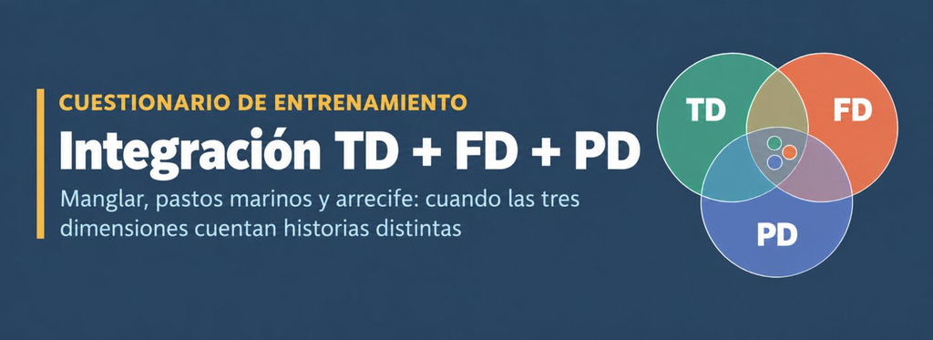

# Propósito

Este cuestionario es una **práctica de entrenamiento** después del Taller 4 (Integración TD + FD + PD) y antes de la asignación 6.2 del estudio de caso. En el caso guiado de peces de México las tres dimensiones ordenaron igual a las zonas; aquí se trabaja una comunidad simulada en la que **cuentan historias distintas**, para practicar la pregunta central de la Unidad IV:

> ¿Cuándo coinciden y cuándo divergen TD, FD y PD, y qué mecanismo ecológico puede explicar cada caso?

La simulación está inspirada en tres hábitats costeros del Caribe colombiano: **manglar (MG)**, **pradera de pastos marinos (PM)** y **arrecife coralino (AR)**, como los de la bahía de Cartagena, las islas del Rosario o el Parque Tayrona. Las especies y los números son ficticios, pero los géneros, las familias y sus dietas son típicos de esos ambientes. La secuencia reproduce el flujo del estudio de caso:

**datos → control de calidad → rasgos y distancia → árbol → A2 (Rao) → redundancia → B1 + B2 (Hill a cobertura común) → coincidencias y divergencias → párrafo de integración.**

Se debe conservar el código, ejecutar los bloques en RStudio, revisar los objetos creados y responder con base en sus propios resultados.

**ImportanteRegla de trabajo**

Cada respuesta debe distinguir entre:

1. **qué se calculó**;
2. **en qué escala** (Q de Rao, números equivalentes o números de Hill, y a qué cobertura);
3. **qué representa ecológicamente**;
4. **qué limitación tiene la comparación**.

# 1. Preparación del entorno

**Código**

```r
library(tidyverse)      # dplyr, tidyr, ggplot2, purrr
library(ape)            # árbol y distancia filogenética
library(FD)             # gowdis(): distancia funcional con rasgos mixtos
library(iNEXT.3D)       # estimate3D(), DataInfo3D(): Hill alfa (B1)
library(iNEXT.beta3D)   # iNEXTbeta3D(): Hill beta (B2)
library(kableExtra)     # Tablas con formato

source("Rao.R")          # Rao(): partición de Rao en TD, FD y PD (A2)
source("alineador.R")    # alinear_beta(): pares alineados con el árbol
source("integrar_3d.R")  # integrar_3d(): la función de la sección 4 del Taller 4

# Formato común de tablas (coma decimal)
source("formato.R")
```

### Pregunta 1

Para cada dimensión (TD, FD y PD), indique **qué insumo adicional** a la matriz de abundancias necesita y **con qué objeto de R** entra a `Rao()` y a `integrar_3d()`. ¿Por qué el árbol entra como distancia a `Rao()` pero como objeto `phylo` a `iNEXT.3D`?

# 2. Simulación de la comunidad

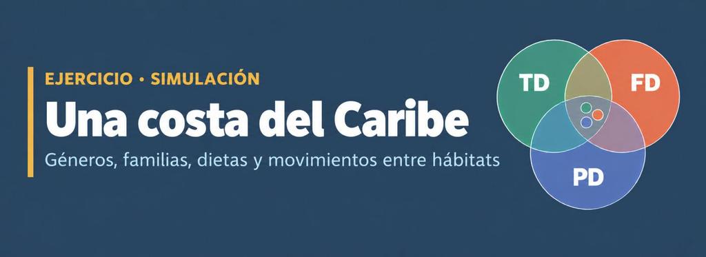

## 2.1 Sitios y hábitats

**Código**

```r
set.seed(2026)                                     # Simulación es reproducible

meta <- tibble(
  Sitio   = paste0("S", sprintf("%02d", 1:36)),    # 36 sitios
  Habitat = rep(c("MG", "PM", "AR"), each = 12)    # 12 por hábitat
)
```

## 2.2 Géneros, clasificación y rasgos de referencia

Cada género tiene su hábitat principal, un nivel trófico, una dieta, una talla típica, una posición en la columna de agua y un **peso** que indica qué tan común es en su hábitat.

**Nota**

La clasificación está simplificada con fines didácticos. *Pomacentridae* se ubica en el clado **Ovalentaria**, que en varias clasificaciones recientes no tiene un orden asignado; aquí se usa como si fuera un orden. En un estudio de caso, la fuente de la clasificación (y su versión) se declara en los métodos.

**Código**

```r
generos <- tribble(
  ~Orden,             ~Familia,         ~Genero,         ~n, ~Habitat, ~TL, ~Dieta,        ~Talla, ~Posicion,       ~Peso,
  "Perciformes",      "Gerreidae",      "Eucinostomus",   5, "MG",     3.1, "invertivoro",    15, "demersal",        1,
  "Perciformes",      "Gerreidae",      "Gerres",         3, "MG",     3.2, "invertivoro",    25, "demersal",        1,
  "Perciformes",      "Gerreidae",      "Diapterus",      3, "MG",     3.1, "invertivoro",    25, "demersal",        1,
  "Perciformes",      "Gerreidae",      "Eugerres",       3, "MG",     3.1, "invertivoro",    30, "demersal",        1,
  "Perciformes",      "Centropomidae",  "Centropomus",    2, "MG",     4.2, "piscivoro",      80, "demersal",        0.6,
  "Mugiliformes",     "Mugilidae",      "Mugil",          2, "MG",     2.0, "detritivoro",    40, "bentopelagico",   0.6,
  "Perciformes",      "Lutjanidae",     "Lutjanus",       4, "PM",     3.8, "piscivoro",      45, "demersal",        1,
  "Perciformes",      "Haemulidae",     "Haemulon",       4, "PM",     3.3, "invertivoro",    25, "demersal",        1,
  "Labriformes",      "Labridae",       "Halichoeres",    3, "PM",     3.3, "invertivoro",    15, "demersal",        1,
  "Labriformes",      "Scaridae",       "Sparisoma",      3, "PM",     2.0, "herbivoro",      30, "demersal",        1,
  "Clupeiformes",     "Engraulidae",    "Anchoa",         2, "PM",     3.0, "planctivoro",     8, "pelagico",        1,
  "Labriformes",      "Scaridae",       "Scarus",         3, "AR",     2.0, "herbivoro",      30, "demersal",        3,
  "Acanthuriformes",  "Acanthuridae",   "Acanthurus",     3, "AR",     2.0, "herbivoro",      25, "demersal",        3,
  "Ovalentaria",      "Pomacentridae",  "Stegastes",      3, "AR",     2.2, "herbivoro",      10, "demersal",        3,
  "Ovalentaria",      "Pomacentridae",  "Abudefduf",      2, "AR",     2.8, "planctivoro",    15, "bentopelagico",   0.5,
  "Ovalentaria",      "Pomacentridae",  "Chromis",        2, "AR",     3.0, "planctivoro",    10, "bentopelagico",   0.5,
  "Acanthuriformes",  "Chaetodontidae", "Chaetodon",      2, "AR",     3.2, "invertivoro",    12, "demersal",        0.5,
  "Perciformes",      "Serranidae",     "Epinephelus",    2, "AR",     4.0, "piscivoro",      70, "demersal",        0.4,
  "Perciformes",      "Serranidae",     "Cephalopholis",  1, "AR",     4.0, "piscivoro",      35, "demersal",        0.4,
  "Holocentriformes", "Holocentridae",  "Holocentrus",    2, "AR",     3.4, "invertivoro",    25, "demersal",        0.5,
  "Holocentriformes", "Holocentridae",  "Myripristis",    1, "AR",     3.2, "planctivoro",    20, "bentopelagico",   0.5
)

taxo <- generos %>%
  uncount(n, .id = "k") %>%                                         # Una fila por especie
  mutate(Especie = paste0(Genero, " sp", sprintf("%02d", k)))       # Morfoespecies: "Eucinostomus sp01"

taxo %>% count(Habitat, Familia, name = "Especies") %>%
  pivot_wider(names_from = Habitat, values_from = Especies, values_fill = 0) %>%
  tabla("Especies por familia y hábitat principal", digits = 0)
```

Especies por familia y hábitat principal

| Familia | AR | MG | PM |
| --- | --- | --- | --- |
| Acanthuridae | 3 | 0 | 0 |
| Chaetodontidae | 2 | 0 | 0 |
| Holocentridae | 3 | 0 | 0 |
| Pomacentridae | 7 | 0 | 0 |
| Scaridae | 3 | 0 | 3 |
| Serranidae | 3 | 0 | 0 |
| Centropomidae | 0 | 2 | 0 |
| Gerreidae | 0 | 14 | 0 |
| Mugilidae | 0 | 2 | 0 |
| Engraulidae | 0 | 0 | 2 |
| Haemulidae | 0 | 0 | 4 |
| Labridae | 0 | 0 | 3 |
| Lutjanidae | 0 | 0 | 4 |

### Pregunta 2

Antes de calcular nada, observe la tabla y escriba una **predicción** para cada hábitat:

1. ¿Qué hábitat espera que tenga más especies efectivas (TD)? ¿Y más linajes (PD)?
2. En el arrecife, tres familias de órdenes distintos (*Scaridae*, *Acanthuridae* y *Pomacentridae*) son herbívoras. ¿Qué fila del mapa conceptual del Taller 4 esperaría ver en ese hábitat?
3. El manglar tiene catorce especies de una sola familia, casi todas invertívoras. ¿Qué espera de su redundancia funcional y filogenética?

# 3. Abundancias con estructura ecológica

Cada género es común en su hábitat principal y está ausente en los demás, salvo los que realmente se mueven entre hábitats: juveniles de pargos y roncadores en el manglar, loros entre los pastos y el arrecife. El esfuerzo de muestreo es distinto **a propósito**: el arrecife quedó con muy pocos individuos por sitio.

**Código**

```r
sp   <- taxo$Especie
n_sp <- length(sp)

prob <- matrix(0, nrow = n_sp,
               ncol = 3,
               dimnames = list(sp, c("MG", "PM", "AR")))   # Probabilidad de cada especie en cada hábitat
for (h in c("MG", "PM", "AR")) {
  prob[taxo$Habitat == h, h] <- 0.5 * taxo$Peso[taxo$Habitat == h]   # Común en su hábitat principal
}
# Movimientos reales entre hábitats
prob[taxo$Genero == "Lutjanus",     "MG"] <- 0.10   # Juveniles de pargos en el manglar
prob[taxo$Genero == "Haemulon",     "MG"] <- 0.05   # Juveniles de roncadores en el manglar
prob[taxo$Genero == "Eucinostomus", "PM"] <- 0.06   # Mojarras que salen a los pastos
prob[taxo$Genero == "Lutjanus",     "AR"] <- 0.10   # Pargos adultos en el arrecife
prob[taxo$Genero == "Haemulon",     "AR"] <- 0.10   # Roncadores en el arrecife
prob[taxo$Genero == "Sparisoma",    "AR"] <- 0.25   # Loros que se alimentan en ambos
prob[taxo$Genero == "Scarus",       "PM"] <- 0.08

esfuerzo <- c(MG = 150, PM = 60, AR = 20)            # Individuos esperados por sitio: el arrecife, submuestreado

abundancias <- sapply(seq_len(nrow(meta)),
                      function(i) {
  h <- meta$Habitat[i]                                # Hábitat del sitio
  p <- prob[, h]
  rpois(n_sp, esfuerzo[h] * p / sum(p))               # Conteos de Poisson
})
dimnames(abundancias) <- list(sp, meta$Sitio)        # Especies (filas) x sitios (columnas)

# --- Errores de digitación deliberados, como en una base de datos real ---
rownames(abundancias)[rownames(abundancias) == "Gerres sp02"]    <- "Gerres  sp02"     # Doble espacio
rownames(abundancias)[rownames(abundancias) == "Acanthurus sp01"] <- "Acanturus sp01"  # Error tipográfico
```

## 3.1 Resumen por hábitat

**Código**

```r
abundancias %>%
  as_tibble(rownames = "Especie") %>%
  pivot_longer(-Especie,
               names_to = "Sitio",
               values_to = "Abundancia") %>%   # Formato largo
  left_join(meta, by = "Sitio") %>%
  group_by(Habitat) %>%
  summarise(Sitios     = n_distinct(Sitio),
            Individuos = sum(Abundancia),
            Riqueza    = n_distinct(Especie[Abundancia > 0]),   # Especies con al menos un individuo
            .groups = "drop") %>%
  tabla("Individuos y riqueza observada por hábitat", digits = 0)
```

Individuos y riqueza observada por hábitat

| Habitat | Sitios | Individuos | Riqueza |
| --- | --- | --- | --- |
| AR | 12 | 272 | 29 |
| MG | 12 | 1.732 | 26 |
| PM | 12 | 702 | 24 |

### Pregunta 3

1. ¿Qué hábitat tiene más individuos y cuál más riqueza observada? ¿Coinciden?
2. ¿Qué hábitat está más afectado por el esfuerzo de muestreo? ¿Qué herramienta del curso corrige ese problema y cuál no?

# 4. Control de calidad

[figure not shown]

**Código**

```r
setdiff(rownames(abundancias), taxo$Especie)   # En las abundancias pero no en la clasificación
```

```
[1] "Gerres  sp02"   "Acanturus sp01"
```

**Código**

```r
setdiff(taxo$Especie, rownames(abundancias))   # En la clasificación pero no en las abundancias
```

```
[1] "Gerres sp02"     "Acanthurus sp01"
```

**Código**

```r
rownames(abundancias) <- str_squish(rownames(abundancias))                  # 1) Espacios dobles
rownames(abundancias) <- recode(rownames(abundancias),
                                "Acanturus sp01" = "Acanthurus sp01")       # 2) Tabla explícita de correcciones

stopifnot(setequal(rownames(abundancias), taxo$Especie))                    # Chequeo duro

# Abundancias por hábitat (especies x hábitats), como las zonas del taller
biol_hab <- sapply(c("MG", "PM", "AR"),
                   function(h)
  rowSums(abundancias[, meta$Sitio[meta$Habitat == h]]))
biol_hab <- as.data.frame(biol_hab)

sin_registros <- rownames(biol_hab)[rowSums(biol_hab) == 0]   # Especies de la clasificación sin ningún individuo
sin_registros
```

```
[1] "Myripristis sp01"
```

**Código**

```r
biol_hab <- biol_hab[rowSums(biol_hab) > 0, ]  # Se excluyen: no aportan a ninguna dimensión
taxo     <- taxo %>%
  filter(Especie %in% rownames(biol_hab))   # Clasificación se ajusta a especies presentes
dim(biol_hab)
```

```
[1] 54  3
```

### Pregunta 4

1. ¿Qué tipo de error es cada uno de los dos detectados con `setdiff()`? ¿Cuál detendría el código y cuál cambiaría los resultados **en silencio**?
2. `sin_registros` muestra una especie que está en la clasificación pero no tiene individuos. ¿Por qué se excluye de la matriz, del árbol **y** de los rasgos? ¿Qué pasaría con `Rao()` si quedara en la distancia pero no en la matriz?

# 5. Rasgos funcionales y árbol

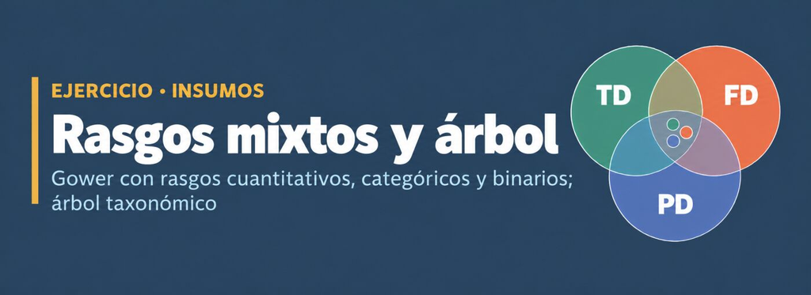

## 5.1 Rasgos mixtos y distancia de Gower

Se usan dos rasgos cuantitativos (nivel trófico y talla), uno categórico (posición en la columna de agua) y cinco binarios de dieta: la combinación que pide la ruta mínima del estudio de caso.

**Código**

```r
rasgos <- taxo %>%
  transmute(
    Especie,
    TrophicLevel = round(TL + rnorm(n(), 0, 0.1), 2),             # Cuantitativo: varía un poco dentro del género
    BodyLength   = round(Talla * exp(rnorm(n(), 0, 0.15)), 1),    # Cuantitativo: talla en cm
    Posicion     = factor(Posicion),                              # Categórico (factor): Gower lo trata como igual/distinto
    herbivoro    = as.integer(Dieta == "herbivoro"),              # Binarios de dieta
    invertivoro  = as.integer(Dieta == "invertivoro"),
    piscivoro    = as.integer(Dieta == "piscivoro"),
    planctivoro  = as.integer(Dieta == "planctivoro"),
    detritivoro  = as.integer(Dieta == "detritivoro")
  ) %>%
  column_to_rownames("Especie")

rasgos <- rasgos[rownames(biol_hab), ]                            # Mismo orden que la matriz de abundancias
stopifnot(identical(rownames(rasgos), rownames(biol_hab)))

vars_bin <- c("herbivoro", "invertivoro", "piscivoro", "planctivoro", "detritivoro")
fd_dist  <- gowdis(rasgos, asym.bin = match(vars_bin, colnames(rasgos)))   # Binarios asimétricos: compartir un 0 no es parecido
```

## 5.2 Árbol taxonómico y distancia cofenética

**Código**

```r
# Misma función del Cuestionario de PD: cada nivel de la clasificación es un nodo
arbol_taxonomico <- function(tabla, niveles) {
  t <- as.data.frame(lapply(tabla[, niveles],
                            function(x) factor(gsub(" ", "_", trimws(x)))))   # Espacios -> guion bajo
  formula_tax <- as.formula(paste("~",
                                  paste(niveles,
                                  collapse = "/")))       # ~Orden/Familia/Genero/Especie
  a <- ape::as.phylo(formula_tax, data = t, collapse = FALSE)               # Árbol jerárquico
  a <- ape::compute.brlen(a, method = "Grafen")           # Longitudes de rama por convención
  a$root.edge <- 0                                        # Marca la raíz
  a$tip.label <- gsub("_", " ", a$tip.label)              # Restaura los espacios
  a
}

arbol <- arbol_taxonomico(taxo, c("Orden", "Familia",
                                  "Genero", "Especie"))
stopifnot(setequal(arbol$tip.label,
                   rownames(biol_hab)))                # Árbol y matriz: mismas especies

phydist <- cophenetic(arbol)[rownames(biol_hab),
                             rownames(biol_hab)]       # Distancia en el orden de la matriz
phylo.d <- as.dist(phydist / max(phydist))             # Reescalada a [0, 1], como Gower
```

### Pregunta 5

1. ¿Por qué `Posicion` se convierte en `factor` antes de `gowdis()`? ¿Qué haría Gower si quedara como texto o como número (1, 2, 3)?
2. Compare `as.matrix(fd_dist)["Scarus sp01", "Acanthurus sp01"]` con `as.matrix(phylo.d)["Scarus sp01", "Acanthurus sp01"]`. ¿Qué dice esa diferencia sobre estas dos especies?
3. Con un árbol taxonómico, ¿qué mide la PD?

# 6. A2 — Partición de Rao y la trampa de la escala

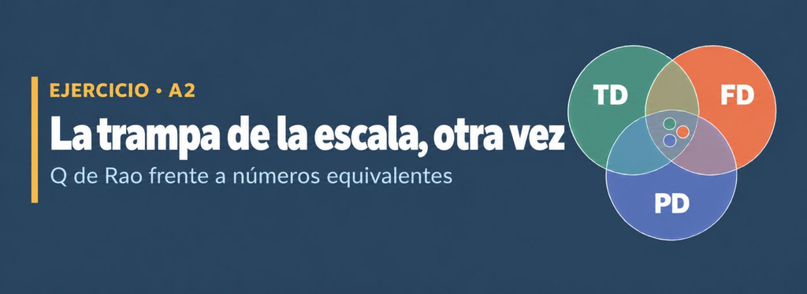

**Código**

```r
stopifnot(identical(labels(fd_dist), rownames(biol_hab)),     # Rao() empareja por posición: mismo orden en los tres objetos
          identical(labels(phylo.d), rownames(biol_hab)))

rao_Q    <- Rao(biol_hab,
                dfunc = fd_dist,
                dphyl = phylo.d,
                weight = FALSE,
                Jost = FALSE)            # Q de Rao
rao_jost <- Rao(biol_hab,
                dfunc = fd_dist,
                dphyl = phylo.d,
                weight = FALSE,
                Jost = TRUE)             # Números equivalentes

particion <- function(r, escala) map_dfr(c("TD", "FD", "PD"),
                                         function(d) tibble(
  Escala = escala, Dimension = d,
  `Alfa media` = r[[d]]$Mean_Alpha, Gamma = r[[d]]$Gamma,
  `Beta prop. (%)` = r[[d]]$Beta_prop))   # % de la diversidad regional x dif. entre hábitats

part <- bind_rows(particion(rao_Q, "Q de Rao"),
                  particion(rao_jost, "Números equivalentes"))
part %>% tabla("Partición de Rao entre los tres hábitats") %>%
  pack_rows(index = table(fct_inorder(part$Escala)))
```

Partición de Rao entre los tres hábitats

| Escala | Dimension | Alfa media | Gamma | Beta prop. (%) |
| --- | --- | --- | --- | --- |
| **Q de Rao** |  |  |  |  |
| Q de Rao | TD | 0,940 | 0,977 | 3,808 |
| Q de Rao | FD | 0,293 | 0,402 | 27,000 |
| Q de Rao | PD | 0,590 | 0,776 | 23,920 |
| **Números equivalentes** |  |  |  |  |
| Números equivalentes | TD | 16,699 | 44,129 | 62,158 |
| Números equivalentes | FD | 1,415 | 1,671 | 15,347 |
| Números equivalentes | PD | 2,440 | 4,457 | 45,262 |

### Pregunta 6

1. Ordene las tres dimensiones según la beta proporcional, primero con *Q* de Rao y luego en números equivalentes. ¿Se repite la trampa de la escala del Taller 4?
2. ¿Cuál de los dos órdenes usaría para afirmar que los hábitats “difieren más en especies que en funciones”? Justifique con el concepto de saturación de Gini-Simpson.

# 7. Redundancia y originalidad

**Código**

```r
redundancia <- tibble(
  Habitat = colnames(biol_hab),
  R_FD = 1 - as.numeric(rao_Q$FD$Alpha / rao_Q$TD$Alpha),   # Redundancia funcional (Ricotta et al. 2016)
  R_PD = 1 - as.numeric(rao_Q$PD$Alpha / rao_Q$TD$Alpha)    # Redundancia filogenética
)
tabla(redundancia, "Redundancia funcional y filogenética por hábitat", digits = 2)
```

Redundancia funcional y filogenética por hábitat

| Habitat | R_FD | R_PD |
| --- | --- | --- |
| MG | 0,77 | 0,62 |
| PM | 0,56 | 0,28 |
| AR | 0,74 | 0,21 |

### Pregunta 7

1. Clasifique cada hábitat en una fila del mapa conceptual del Taller 4 (redundancia, convergencia funcional, divergencia de rasgos o complementariedad), usando **las dos columnas** a la vez.
2. El arrecife tiene redundancia funcional alta y redundancia filogenética baja. ¿Qué especies lo explican? ¿Se cumplió su predicción de la Pregunta 2?
3. ¿Por qué se usa la *Q* sin transformar (y no números equivalentes) para calcular *R*?

# 8. B1 + B2 — Las tres dimensiones a cobertura común

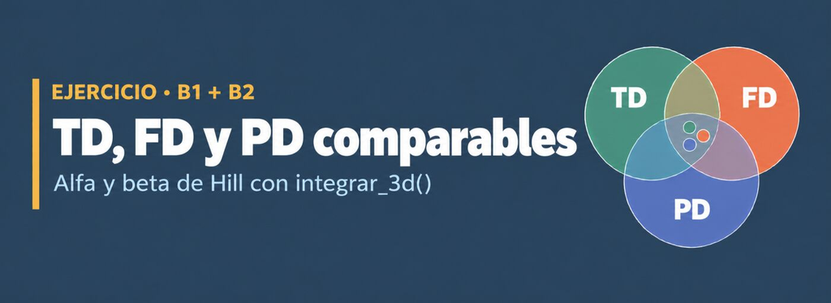

**Código**

```r
int <- integrar_3d(biol_hab, fd_dist, arbol)              # La misma función del Taller 4
c(Alfa = int$cobertura_alfa, Beta = int$cobertura_beta)   # Coberturas comunes
```

```
     Alfa      Beta
0.9817790 0.9948792
```

**Código**

```r
int$info                                                  # n, S.obs y SC(n) por hábitat
```

```
  Assemblage    n S.obs    SC(n)    SC(2n) f1 f2 f3 f4 f5
1         MG 1732    26 1.000000 1.0000000  0  0  0  0  0
2         PM  702    24 1.000000 1.0000000  0  0  1  1  4
3         AR  272    29 0.981779 0.9983441  5  6  3  2  0
```

## 8.1 Alfa

**Código**

```r
int$alfa %>%
  pivot_wider(names_from = Dimension,
              values_from = Valor) %>%
  arrange(Order.q, Unidad) %>%
  tabla("Diversidad alfa en números de Hill a cobertura común", digits = 2)
```

Diversidad alfa en números de Hill a cobertura común

| Unidad | Order.q | TD | FD | PD |
| --- | --- | --- | --- | --- |
| AR | 0 | 29,00 | 4,73 | 7,04 |
| MG | 0 | 23,81 | 3,86 | 4,98 |
| PM | 0 | 21,92 | 4,20 | 4,98 |
| AR | 1 | 17,34 | 2,80 | 4,35 |
| MG | 1 | 19,69 | 2,56 | 2,27 |
| PM | 1 | 17,99 | 3,79 | 3,61 |
| AR | 2 | 13,89 | 2,25 | 3,74 |
| MG | 2 | 17,70 | 2,17 | 1,55 |
| PM | 2 | 16,42 | 3,52 | 3,09 |

**Código**

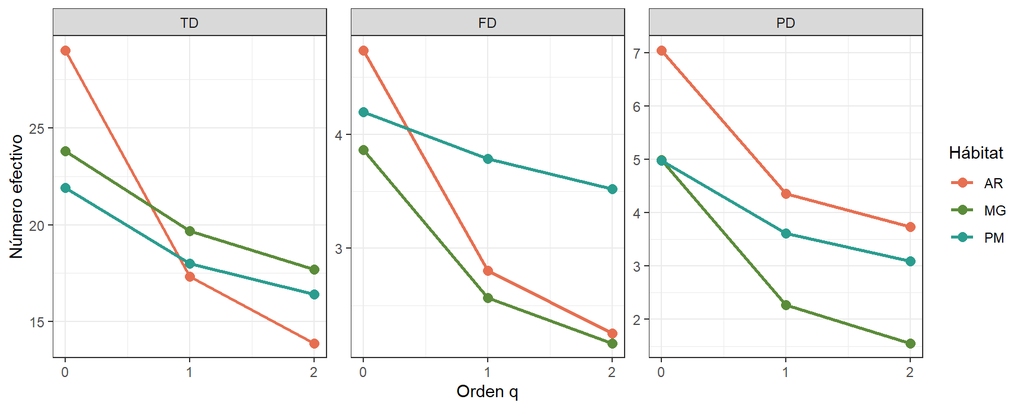

```r
int$alfa %>%
  mutate(Dimension = factor(Dimension,
                            levels = c("TD", "FD", "PD"))) %>%
  ggplot(aes(Order.q, Valor,
             color = Unidad)) +
  geom_line(linewidth = 0.9) +
  geom_point(size = 2.6) +
  facet_wrap(~ Dimension,
             scales = "free_y") +         # Cada dimensión en su propia escala
  scale_color_manual(values = cols_hab) +
  scale_x_continuous(breaks = 0:2) +
  scale_y_continuous(labels = coma) +
  labs(x = "Orden q",
       y = "Número efectivo",
       color = "Hábitat") +
  theme_bw(base_size = 11)
```

### Pregunta 8

1. ¿Qué hábitat fija la cobertura común y por qué?
2. Para q = 2, ordene los hábitats en cada dimensión. ¿Coinciden los tres órdenes?
3. El manglar tiene la mayor TD con q = 1 y 2, pero la menor PD. Explíquelo con la tabla de la sección 2.2.

## 8.2 Beta

**Código**

```r
int$beta %>%
  dplyr::select(-Disimilitud) %>%
  pivot_wider(names_from = Dimension,
              values_from = Beta) %>%
  arrange(Order.q, Par) %>%
  tabla("Beta de Hill entre pares de hábitats a cobertura común (1 a 2)", digits = 2)
```

Beta de Hill entre pares de hábitats a cobertura común (1 a 2)

| Par | Order.q | TD | FD | PD |
| --- | --- | --- | --- | --- |
| MG_vs_AR | 0 | 1,77 | 1,22 | 1,72 |
| MG_vs_PM | 0 | 1,47 | 1,23 | 1,49 |
| PM_vs_AR | 0 | 1,52 | 1,07 | 1,51 |
| MG_vs_AR | 1 | 1,96 | 1,70 | 1,94 |
| MG_vs_PM | 1 | 1,68 | 1,26 | 1,53 |
| PM_vs_AR | 1 | 1,76 | 1,30 | 1,59 |
| MG_vs_AR | 2 | 1,98 | 1,85 | 1,97 |
| MG_vs_PM | 2 | 1,75 | 1,38 | 1,54 |
| PM_vs_AR | 2 | 1,84 | 1,38 | 1,61 |

**Código**

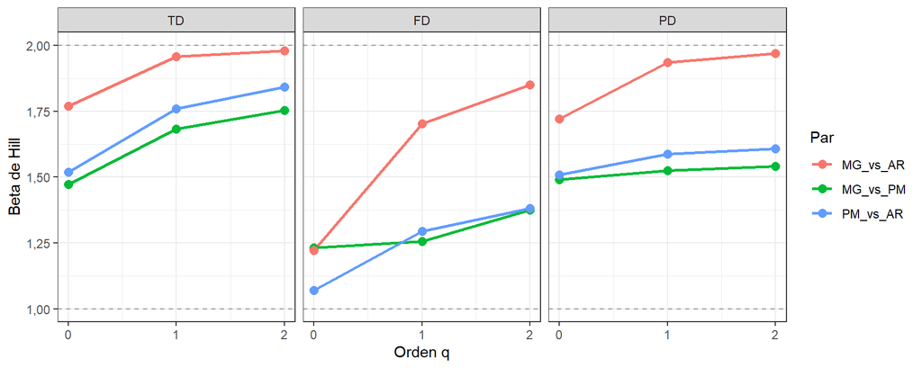

```r
int$beta %>%
  mutate(Dimension = factor(Dimension,
                     levels = c("TD", "FD", "PD"))) %>%
  ggplot(aes(Order.q, Beta, color = Par)) +
  geom_hline(yintercept = c(1, 2),
             linetype = "dashed",
             color = "grey60") +
  geom_line(linewidth = 0.9) +
  geom_point(size = 2.6) +
  facet_wrap(~ Dimension) +        # Misma escala (1 a 2) en los tres paneles
  scale_x_continuous(breaks = 0:2) +
  scale_y_continuous(limits = c(1, 2),
                     labels = coma) +
  labs(x = "Orden q",
       y = "Beta de Hill",
       color = "Par") +
  theme_bw(base_size = 11)
```

### Pregunta 9

1. Con q = 1 y q = 2, ¿qué par de hábitats es el más diferenciado en las tres dimensiones? ¿Pasa lo mismo con q = 0?
2. Entre pastos marinos y arrecife, compare la beta TD y la beta FD con q = 0. ¿Qué mecanismo sugiere la diferencia? (pista: ¿quiénes son los herbívoros en cada hábitat?).
3. ¿Por qué la beta FD aumenta tanto al pasar de q = 0 a q = 2 en casi todos los pares?

# 9. ¿Coinciden o divergen?

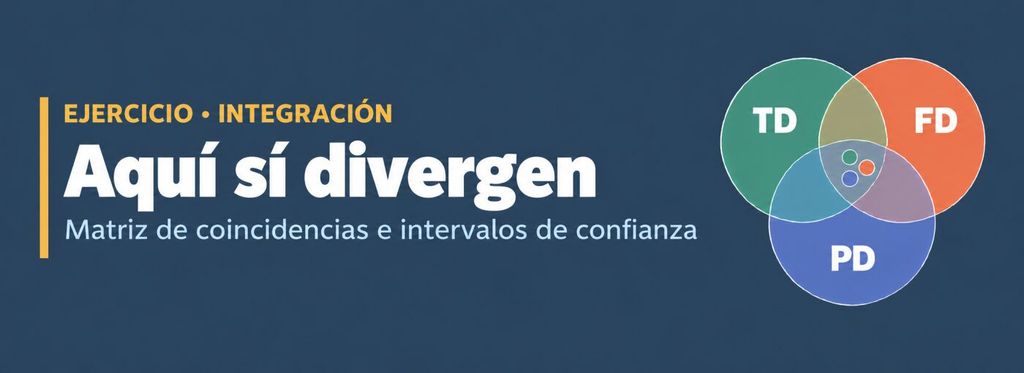

**Código**

```r
orden_txt <- function(valor, nombre) paste(nombre[order(-valor)],
                                           collapse = " > ")   # "AR > PM > MG"

matriz <- bind_rows(
  int$alfa %>%
    group_by(Escala = "Alfa", Order.q, Dimension) %>%
    summarise(Orden = orden_txt(Valor, Unidad),
              .groups = "drop"),
  int$beta %>%
    group_by(Escala = "Beta",
             Order.q, Dimension) %>%
    summarise(Orden = orden_txt(Beta, Par),
              .groups = "drop")
) %>%
  pivot_wider(names_from = Dimension,
              values_from = Orden) %>%
  mutate(`¿Coinciden?` = if_else(TD == FD & TD == PD,
                                 "Coinciden", "Divergen")) %>%
  dplyr::select(Escala, Order.q, TD, FD, PD, `¿Coinciden?`)   # Columnas en orden TD, FD, PD

tabla(matriz, "Matriz de coincidencias entre dimensiones") %>%
  column_spec(6, bold = TRUE,
              color = if_else(matriz$`¿Coinciden?` == "Coinciden",
                              "#1B7F79", "#B03A2E"))
```

Matriz de coincidencias entre dimensiones

| Escala | Order.q | TD | FD | PD | ¿Coinciden? |
| --- | --- | --- | --- | --- | --- |
| Alfa | 0 | AR > MG > PM | AR > PM > MG | AR > MG > PM | Divergen |
| Alfa | 1 | MG > PM > AR | PM > AR > MG | AR > PM > MG | Divergen |
| Alfa | 2 | MG > PM > AR | PM > AR > MG | AR > PM > MG | Divergen |
| Beta | 0 | MG_vs_AR > PM_vs_AR > MG_vs_PM | MG_vs_PM > MG_vs_AR > PM_vs_AR | MG_vs_AR > PM_vs_AR > MG_vs_PM | Divergen |
| Beta | 1 | MG_vs_AR > PM_vs_AR > MG_vs_PM | MG_vs_AR > PM_vs_AR > MG_vs_PM | MG_vs_AR > PM_vs_AR > MG_vs_PM | Coinciden |
| Beta | 2 | MG_vs_AR > PM_vs_AR > MG_vs_PM | MG_vs_AR > PM_vs_AR > MG_vs_PM | MG_vs_AR > PM_vs_AR > MG_vs_PM | Coinciden |

## 9.1 ¿Las diferencias son reales?

Con `nboot = 0` no hay intervalos. Aquí se repite la alfa con 20 réplicas para q = 1 y 2.

**Código**

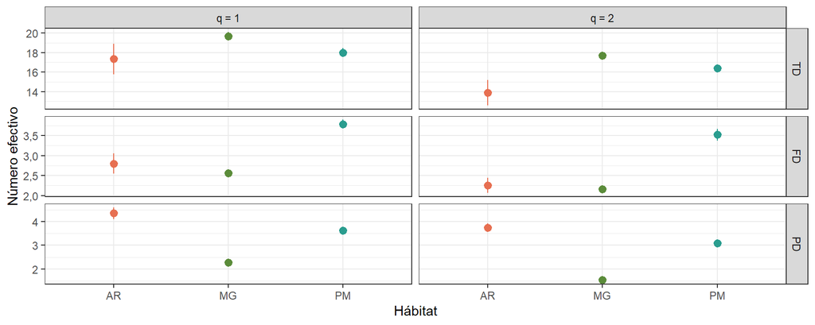

```r
set.seed(2026)                                             # El bootstrap usa números aleatorios
dmat <- as.matrix(fd_dist)
alfa_ic <- bind_rows(
  estimate3D(biol_hab, diversity = "TD",
             q = c(1, 2), datatype = "abundance",
             base = "coverage",
             level = int$cobertura_alfa,
             nboot = 20) %>%
    transmute(Unidad = Assemblage, Order.q,
              Dimension = "TD", Valor = qTD,
              LCL = qTD.LCL, UCL = qTD.UCL),
  estimate3D(biol_hab,
             diversity = "FD", q = c(1, 2),
             datatype = "abundance", base = "coverage",
             level = int$cobertura_alfa,
             nboot = 20, FDdistM = dmat,
             FDtype = "AUC", FDcut_number = 15) %>%
    transmute(Unidad = Assemblage, Order.q,
              Dimension = "FD", Valor = qFD,
              LCL = qFD.LCL, UCL = qFD.UCL),
  estimate3D(biol_hab, diversity = "PD", q = c(1, 2),
             datatype = "abundance", base = "coverage",
             level = int$cobertura_alfa, nboot = 20,
             PDtree = arbol, PDtype = "meanPD") %>%
    transmute(Unidad = Assemblage, Order.q,
              Dimension = "PD", Valor = qPD,
              LCL = qPD.LCL, UCL = qPD.UCL)
)

alfa_ic %>%
  mutate(Dimension = factor(Dimension,
                            levels = c("TD", "FD", "PD"))) %>%
  ggplot(aes(Unidad, Valor, color = Unidad)) +
  geom_pointrange(aes(ymin = LCL, ymax = UCL)) +      # Punto = estimación; línea = IC 95 %
  facet_grid(Dimension ~ paste("q =", Order.q),
             scales = "free_y") +
  scale_color_manual(values = cols_hab, guide = "none") +
  scale_y_continuous(labels = coma) +
  labs(x = "Hábitat", y = "Número efectivo") +
  theme_bw(base_size = 11)
```

### Pregunta 10

1. ¿En qué filas de la matriz divergen las dimensiones? Escriba el orden de cada una para q = 1.
2. Con los intervalos de la figura, ¿qué diferencias del orden son claras y cuáles no se distinguen? Corrija la matriz “a mano” si alguna divergencia depende de valores cuyos intervalos se solapan.
3. ¿Por qué esta comunidad diverge y el caso guiado de México no? Relacione su respuesta con la composición de familias de cada hábitat.

# 10. Sensibilidad: ¿cambia la integración con otros rasgos?

**Código**

```r
rasgos_dieta <- rasgos[, c("TrophicLevel", vars_bin)]                         # Sin talla ni posición
dist_dieta   <- gowdis(rasgos_dieta,
                       asym.bin = match(vars_bin,
                                        colnames(rasgos_dieta)))

rao_dieta <- Rao(biol_hab, dfunc = dist_dieta,
                 dphyl = NULL, weight = FALSE, Jost = FALSE)
int_dieta <- integrar_3d(biol_hab, dist_dieta, arbol)

tibble(Habitat = colnames(biol_hab),
       `R_FD (8 rasgos)`   = redundancia$R_FD,
       `R_FD (solo dieta)` = 1 - as.numeric(rao_dieta$FD$Alpha /
                                              rao_dieta$TD$Alpha)) %>%
  tabla("Redundancia funcional con todos los rasgos y solo con la dieta", digits = 2)
```

Redundancia funcional con todos los rasgos y solo con la dieta

| Habitat | R_FD (8 rasgos) | R_FD (solo dieta) |
| --- | --- | --- |
| MG | 0,77 | 0,73 |
| PM | 0,56 | 0,41 |
| AR | 0,74 | 0,67 |

**Código**

```r
int$alfa %>% filter(Dimension == "FD") %>%
  dplyr::select(Unidad, Order.q, `FD (8 rasgos)` = Valor) %>%
  left_join(int_dieta$alfa %>% filter(Dimension == "FD") %>%
              dplyr::select(Unidad, Order.q,
                            `FD (solo dieta)` = Valor),
            by = c("Unidad", "Order.q")) %>%
  arrange(Order.q, Unidad) %>%
  tabla("FD alfa a cobertura común con dos conjuntos de rasgos", digits = 2)
```

FD alfa a cobertura común con dos conjuntos de rasgos

| Unidad | Order.q | FD (8 rasgos) | FD (solo dieta) |
| --- | --- | --- | --- |
| AR | 0 | 4,73 | 4,93 |
| MG | 0 | 3,86 | 3,84 |
| PM | 0 | 4,20 | 4,61 |
| AR | 1 | 2,80 | 2,66 |
| MG | 1 | 2,56 | 2,51 |
| PM | 1 | 3,79 | 4,14 |
| AR | 2 | 2,25 | 2,04 |
| MG | 2 | 2,17 | 2,10 |
| PM | 2 | 3,52 | 3,82 |

### Pregunta 11

1. ¿En qué hábitat cambia más la redundancia funcional al quitar la talla y la posición? ¿Por qué ese hábitat y no otro?
2. ¿Cambia el **orden** de los hábitats en FD? ¿Qué le dice eso sobre la robustez de la conclusión de la Pregunta 8?
3. En su estudio de caso, ¿qué rasgo quitaría primero en un análisis de sensibilidad y por qué?

# 11. Mini-desafío de depuración

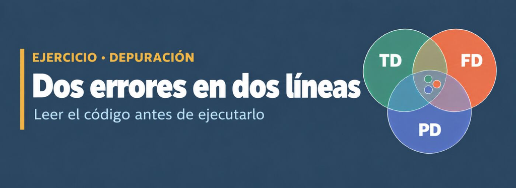

El siguiente código contiene **dos problemas**:

**Código**

```r
rao_error <- Rao(t(biol_hab),
                 dfunc = fd_dist,
                 dphyl = arbol,
                 weight = FALSE,
                 Jost = TRUE)

int_error <- integrar_3d(biol_hab, fd_dist, arbol)
```

### Pregunta 12

Identifique los **dos problemas** sin ejecutar primero el bloque. Para cada uno indique qué está mal, cómo se detectaría en RStudio y cómo se corrige.

**Nota**

La segunda línea no es un error. El ejercicio busca reconocer errores reales, no encontrarlos donde no los hay.

# 12. Interpretación sin código

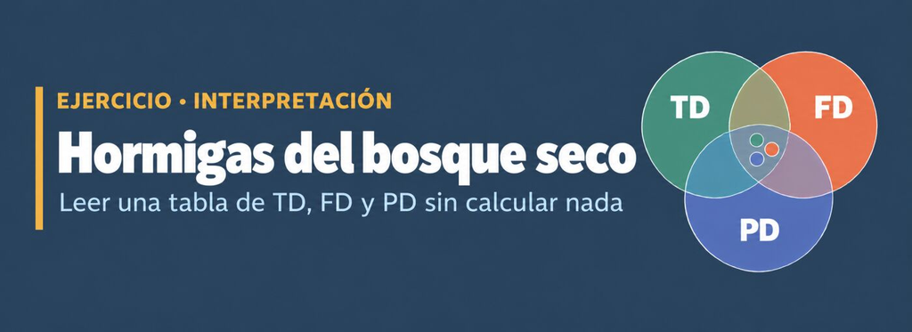

Un grupo trabaja con **hormigas** en tres coberturas de un bosque seco del Caribe (bosque maduro, rastrojo y potrero) y obtiene, a cobertura común y con q = 1:

| Cobertura | TD (especies efectivas) | FD (AUC) | PD (meanPD) | Beta con el bosque maduro (TD / FD / PD) |
| --- | --- | --- | --- | --- |
| Bosque maduro | 22,0 | 4,1 | 7,9 | — |
| Rastrojo | 19,5 | 4,0 | 6,1 | 1,45 / 1,08 / 1,30 |
| Potrero | 9,0 | 2,2 | 5,7 | 1,90 / 1,62 / 1,35 |

### Pregunta 13

1. El rastrojo perdió pocas especies efectivas frente al bosque maduro y casi nada de FD, pero bastante PD. ¿Qué sugiere?
2. El potrero comparte pocas especies y pocas funciones con el bosque maduro, pero conserva una PD alta para su TD. ¿Cómo es posible?
3. ¿Qué fila del mapa conceptual describe mejor la comparación bosque maduro–rastrojo?
4. ¿Qué dato le falta a esta tabla para defender esas conclusiones? (pista: sección 9.1).

# 13. Integración y transferencia

[figure not shown]

### Pregunta 14

Escriba el **párrafo de integración** para la comunidad simulada con la plantilla del Taller 4:

> *“Entre [unidades], TD, FD y PD coinciden en […], pero divergen en […], lo que sugiere […]. Esta lectura está limitada por […].”*

### Pregunta 15

Para la comunidad de **su estudio de caso** (6.2), defina:

- las unidades que va a comparar y si tienen datos suficientes (Taller 4, sección 7);
- los rasgos que usará, cuáles son cuantitativos y cuáles categóricos, y cuál quitaría en un análisis de sensibilidad;
- la fuente del árbol y lo que mide la PD con él;
- **una predicción**: ¿espera que las tres dimensiones coincidan o diverjan? ¿En qué fila del mapa conceptual? Justifique con la biología del grupo.

# 14. Producto esperado

**TipSe espera entregar**

1. El `.qmd` ejecutado y su render (HTML o PDF), con las tablas y figuras del propio documento.
2. Las respuestas a las 15 preguntas, apoyadas en sus resultados.
3. El párrafo de integración (Pregunta 14) y la predicción para su estudio de caso (Pregunta 15).
4. La declaración de uso de IA, si la hubo (bitácora del estudio de caso).

# 15. Criterios de autoevaluación

| Competencia | Inicial | En desarrollo | Consolidada |
| --- | --- | --- | --- |
| Insumos alineados | Ejecuta el código | Detecta errores con `setdiff()` | Corrige con tablas explícitas y verifica el orden en los tres objetos |
| Rasgos mixtos | Usa los rasgos dados | Distingue cuantitativos, categóricos y binarios | Justifica el tratamiento de cada tipo en Gower |
| Escala de comparación | Reporta valores de Rao | Distingue Q, números equivalentes y Hill | Elige la escala correcta para comparar dimensiones |
| Redundancia | Calcula *U* y *R* | Interpreta cada hábitat | Combina *R* funcional y filogenética para proponer un mecanismo |
| Coincidencias y divergencias | Lee la matriz | Distingue orden y magnitud | Revisa intervalos antes de afirmar una divergencia |
| Sensibilidad | Repite un cálculo | Compara resultados | Decide qué conclusiones son robustas |
| Comunicación | Describe números | Usa la plantilla | Escribe un párrafo con mecanismo y limitaciones |

# 16. Cierre

La competencia que se busca fortalecer es pasar de **“sé calcular TD, FD y PD”** a **“sé decir cuándo cuentan la misma historia, cuándo no, y por qué”**. En el estudio de caso, el párrafo de integración pesa más que cualquier número aislado: es ahí donde las tres dimensiones se convierten en ecología.